# Midterm

## 5.3 Everyday I’m Profilin’ (10 points)

#### For your likelihood fit, are your profiles well behaved? For just the slope, use grid sampling to create a profile. You’ll need to write functions for this, and use the results from your glm() fit to provide the reasonable bounds of what you should be profiling over (3SE should do). Is it well behaved? Plot the profile and give the 80% and 95% CI. Verify your results with profileModel.

```r
#data generating proccess, need to make a function

lik_func <- function(slope, intercept, resid_sd){

    morph_fit <- intercept + slope * morph_data$`Tarsus (mm)`

    #likelihood
    sum(dnorm(morph_data$`Culmen (mm)`, morph_fit, resid_sd, log = TRUE))
}


#grid sample

summary(morph_glm) #to get values for grid. Intercept = -0.09871
```

```
##
## Call:
## glm(formula = (morph_data$`Culmen (mm)` ~ morph_data$`Tarsus (mm)`),
##     family = gaussian(link = "identity"), data = morph_data)
##
## Deviance Residuals:
##     Min       1Q   Median       3Q      Max
## -4.4081  -0.7029  -0.0328   0.7263   3.5970
##
## Coefficients:
##                           Estimate Std. Error t value Pr(>|t|)
## (Intercept)              -0.098707   0.215450  -0.458    0.647
## morph_data$`Tarsus (mm)`  0.372927   0.006646  56.116   <2e-16 ***
## ---
## Signif. codes:  0 '***' 0.001 '**' 0.01 '*' 0.05 '.' 0.1 ' ' 1
##
## (Dispersion parameter for gaussian family taken to be 1.533593)
##
##     Null deviance: 6000.9  on 765  degrees of freedom
## Residual deviance: 1171.7  on 764  degrees of freedom
##   (114 observations deleted due to missingness)
## AIC: 2505.4
##
## Number of Fisher Scoring iterations: 2
```

```r
profile(morph_glm, objective = "ordinaryDeviance")
```

```
## $`(Intercept)`
##           tau par.vals.(Intercept) par.vals.morph_data$`Tarsus (mm)`
## 1  -2.5822797          -0.65505818                        0.38971354
## 2  -2.0658238          -0.54378797                        0.38635619
## 3  -1.5493678          -0.43251776                        0.38299883
## 4  -1.0329119          -0.32124755                        0.37964148
## 5  -0.5164559          -0.20997733                        0.37628413
## 6   0.0000000          -0.09870712                        0.37292677
## 7   0.5164559           0.01256309                        0.36956942
## 8   1.0329119           0.12383330                        0.36621206
## 9   1.5493678           0.23510351                        0.36285471
## 10  2.0658238           0.34637372                        0.35949735
## 11  2.5822797           0.45764393                        0.35614000
## 12  3.0987357           0.56891414                        0.35278264
##
## $`morph_data$`Tarsus (mm)``
##           tau par.vals.(Intercept) par.vals.morph_data$`Tarsus (mm)`
## 1  -3.0987357           0.55435785                        0.35233365
## 2  -2.5822797           0.44551369                        0.35576583
## 3  -2.0658238           0.33666952                        0.35919802
## 4  -1.5493678           0.22782536                        0.36263021
## 5  -1.0329119           0.11898120                        0.36606240
## 6  -0.5164559           0.01013704                        0.36949458
## 7   0.0000000          -0.09870712                        0.37292677
## 8   0.5164559          -0.20755129                        0.37635896
## 9   1.0329119          -0.31639545                        0.37979115
## 10  1.5493678          -0.42523961                        0.38322333
## 11  2.0658238          -0.53408377                        0.38665552
## 12  2.5822797          -0.64292793                        0.39008771
##
## attr(,"original.fit")
##
## Call:  glm(formula = (morph_data$`Culmen (mm)` ~ morph_data$`Tarsus (mm)`),
##     family = gaussian(link = "identity"), data = morph_data)
##
## Coefficients:
##              (Intercept)  morph_data$`Tarsus (mm)`
##              -0.09870712                0.37292677
##
## Degrees of Freedom: 765 Total (i.e. Null);  764 Residual
```

[output cut: 16 more lines]

```
## morph_data$`Tarsus (mm)`  0.372926771  0.006645654 56.11589  < 2e-16 ***
## ---
## Signif. codes:  0 '***' 0.001 '**' 0.01 '*' 0.05 '.' 0.1 ' ' 1
##
## (Dispersion parameter for gaussian family taken to be 1.533593)
##
##     Null deviance: 6000.9406  on 765  degrees of freedom
## Residual deviance: 1171.6654  on 764  degrees of freedom
##   (114 observations deleted due to missingness)
## AIC: 2505.3633
##
## Number of Fisher Scoring iterations: 2
##
## attr(,"class")
## [1] "profile.glm" "profile"
```

[figure not shown]

```r
#range of slope values (3SE)

morph_grid <- crossing(slope = seq(0.25, 0.45, 0.005),
                        intercept = seq(-.75, -0.09871, .75),
                        resid_sd = .5, 1.5, .05) %>%
  rowwise() %>%
  mutate(logl = lik_func(slope, intercept, resid_sd)) %>%
  ungroup()


#get our profiles so we can get the CI, looking via slope
slope_prof <- morph_grid %>%
  group_by(slope) %>%
  filter(logl == max(logl)) %>% #filtering for max likelihood
  ungroup()

#plot profile
slope_prof_plot <- ggplot(slope_prof,
       mapping = aes(x = slope, y = logl)) +
  geom_line() +  xlim(0.35,0.39)+ ylim(-1260,-1248) #zoom in

slope_prof_plot  #nothing plots? (couldn't answer if it behaves without plot)
```

```r
#give the 95% CI.
#profile
slope_prof %>%
  filter(logl >= max(logl) - 1.96) %>% #1.96SE = CI
  arrange(slope) %>%
  filter(row_number()==1 | row_number()== n()) %>%
  as.data.frame()
```

```
## [1] slope     intercept resid_sd  1.5       0.05      logl
## <0 rows> (or 0-length row.names)
```

```r
#give the 80% CI.
#profile
slope_prof %>%
  filter(logl >= max(logl) - 1.28) %>% #z value 1.28 = 80%CI
  arrange(slope) %>%
  filter(row_number()==1 | row_number()== n()) %>%
  as.data.frame()
```

```
## [1] slope     intercept resid_sd  1.5       0.05      logl
## <0 rows> (or 0-length row.names)
```

```r
#Verify your results with profileModel

prof_mod <- profileModel(morph_glm,
                              objective = "ordinaryDeviance")
```

```
## Profiling for parameter (Intercept) ... Done
## Profiling for parameter morph_data$`Tarsus (mm)` ... Done
```

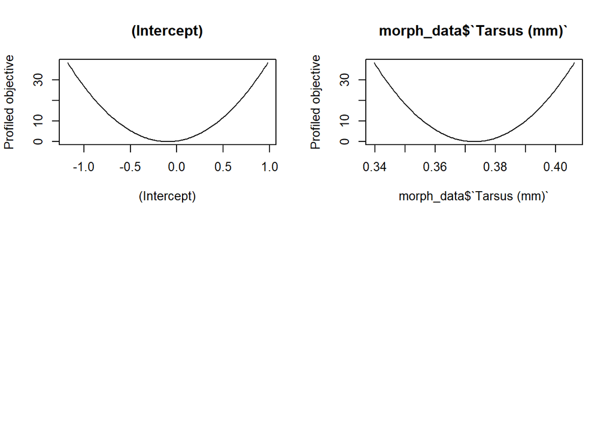

```r
plot(prof_mod)
```

## 5.4 The Power of the Prior (10 points)

#### This data set is pretty big. After excluding NAs in the variables we’re interested in, it’s over 766 lines of data! Now, a lot of data can overhwelm a strong prior. But only to a point. Show first that there is enough data here that a prior for the slope with an estimate of 0.4 and a sd of 0.01 is overwhelmed by the data by demonstrating that it produces similar results to our already fit flat prior. Second, see if a very small sample size (n = 10) would at least include 0.4 in it’s 95% Credible Interval. Last, demonstrate at what sample size that 95% CL first begins to include 0.4 when we have a strong prior. How much data do we really need to overcome our prior belief? Note, it takes a long time to fit these models, so, try a strategy of spacing out the 3-4 sample sizes, and then zoom in on an interesting region.

#### Show first that there is enough data here that a prior for the slope with an estimate of 0.4 and a sd of 0.01 is overwhelmed by the data by demonstrating that it produces similar results to our already fit flat prior.

```r
prior_summary(morph_bayes)
```

```
##                  prior     class        coef group resp dpar nlpar bound
## 1                              b
## 2                              b Tarsus..mm.
## 3 student_t(3, 12, 10) Intercept
## 4  student_t(3, 0, 10)     sigma
```

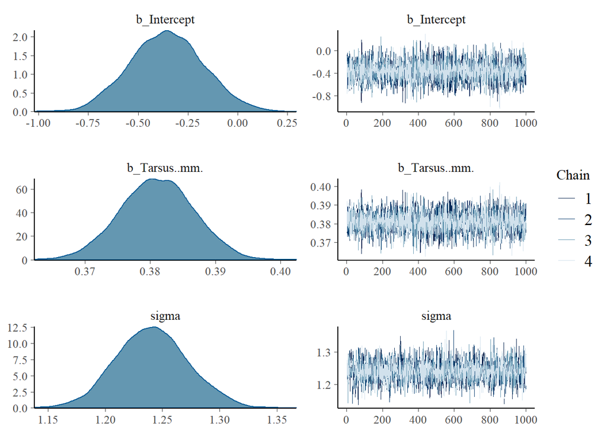

```r
morph_bayes_prior <- brm(Culmen..mm.~ Tarsus..mm.,
                         family = gaussian(link = "identity"),
                         data = morph_data_csv,
                         prior = c(
                           prior(normal(0.4,0.01))),
                         file = "./morph_bayes_prior.rds")  #NAs were excluded from model

#checking assumptions:

#look at chains:
plot(morph_bayes_prior)  #looks normal
```

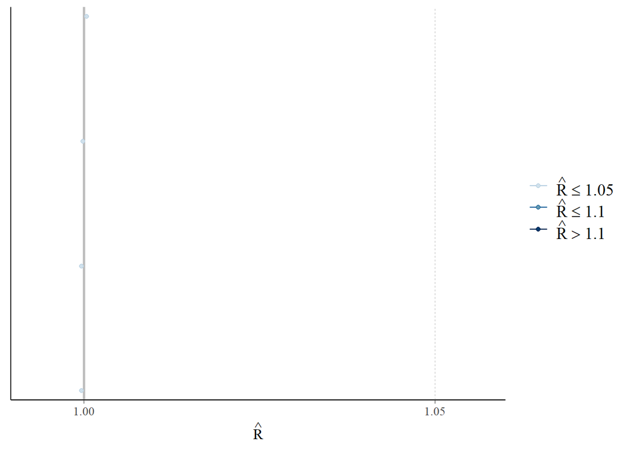

```r
#Inspect rhat
mcmc_rhat(rhat(morph_bayes_prior))  #almost all close to 1, so good
```

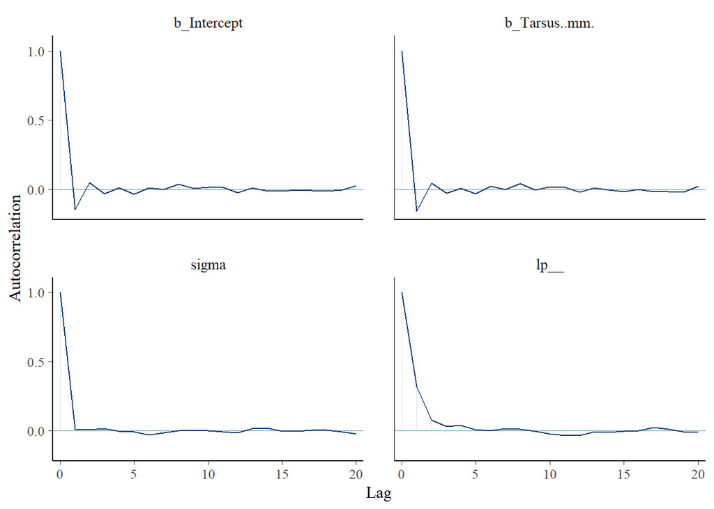

```r
#Inspect Autocorrelation
mcmc_acf(as.data.frame(morph_bayes_prior))  #autocorrelation drops off really quickly, so looks good
```

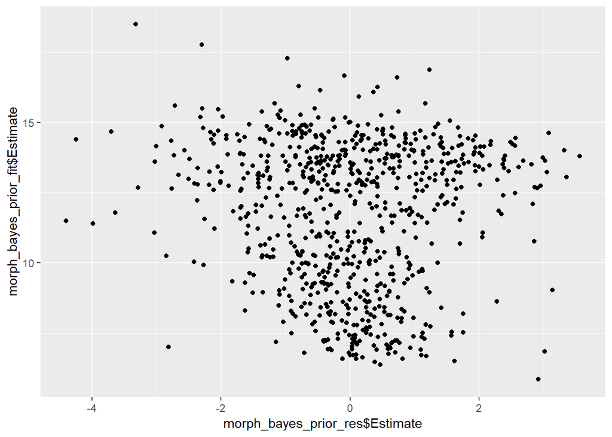

```r
#testing assumptions:

#model assumptions
morph_bayes_prior_fit <- predict(morph_bayes_prior) %>% as_tibble
morph_bayes_prior_res <- residuals(morph_bayes_prior) %>% as_tibble

qplot(morph_bayes_prior_res$Estimate, morph_bayes_prior_fit$Estimate)  #no patterns in fitted vs residuals, so good about gaussian model
```

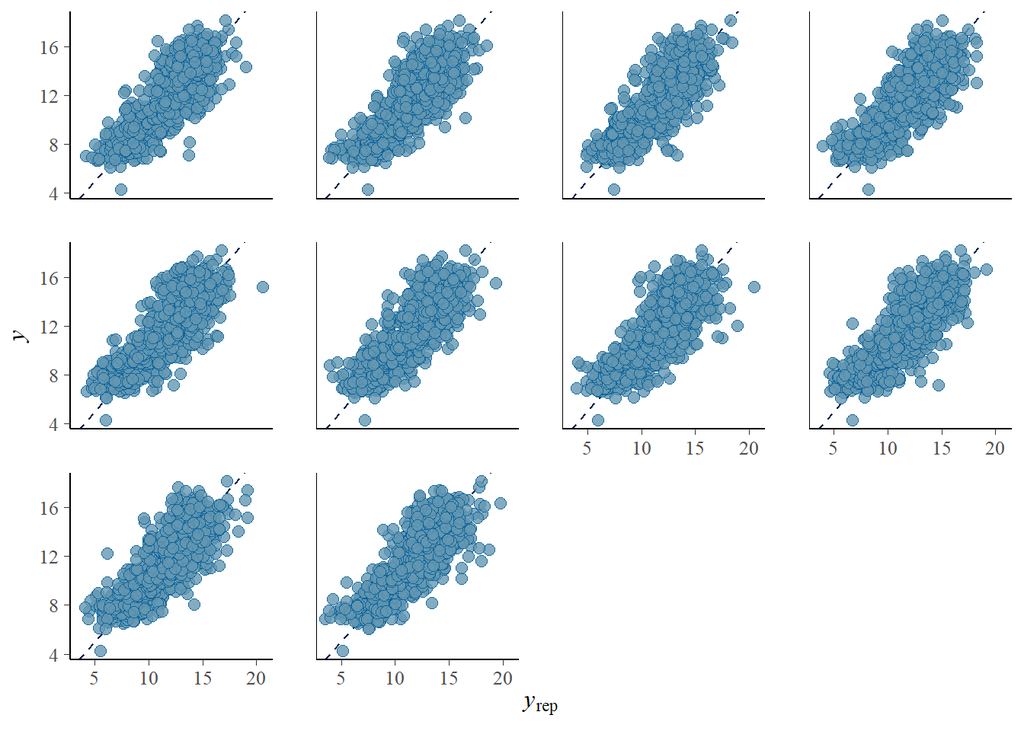

```r
#fit
pp_check(morph_bayes_prior, type ="scatter") #do observed and fitted match up? pretty good predictions
```

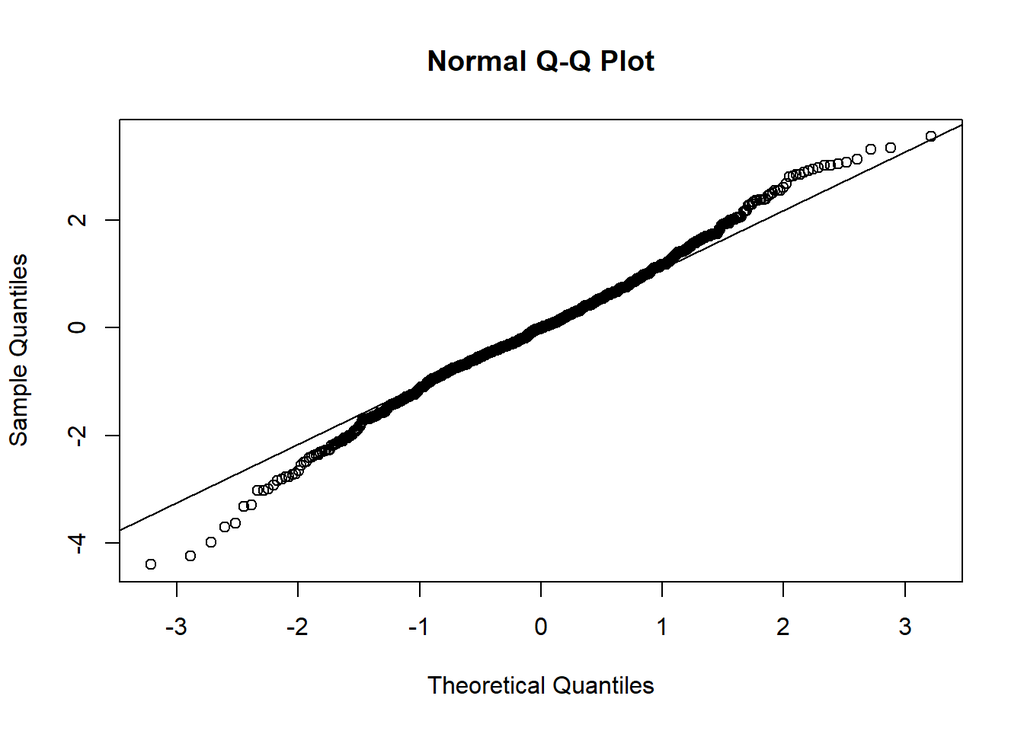

```r
#normality
qqnorm(morph_bayes_prior_res$Estimate)
qqline(morph_bayes_prior_res$Estimate) #fits pretty ok, tails slightly off
```

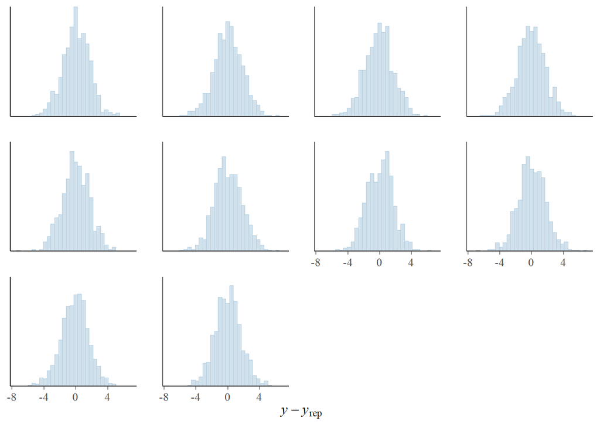

```r
pp_check(morph_bayes_prior, type="error_hist", bins = 8)  #each histogram looks pretty normal
```

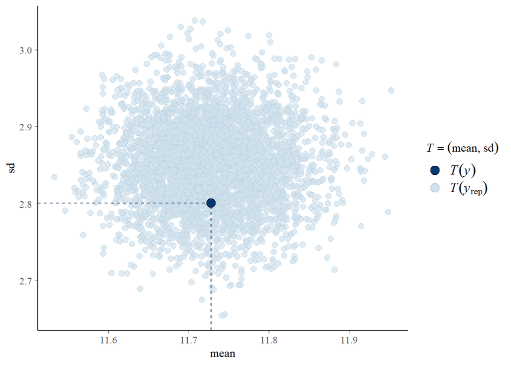

```r
##match to posterior
pp_check(morph_bayes_prior, type="stat_2d", test=c("mean", "sd")) #Stat 2d pretty good point cloud
```

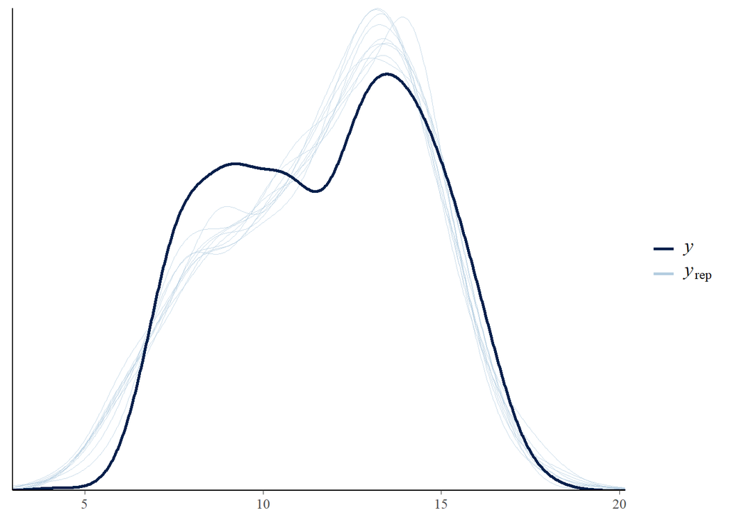

```r
pp_check(morph_bayes_prior) #pretty nice of distribution
```

```r
posterior_interval(morph_bayes_prior)
```

```
##                        2.5%         97.5%
## b_Intercept      -0.7087918  4.852717e-03
## b_Tarsus..mm.     0.3701591  3.918707e-01
## sigma             1.1798197  1.304322e+00
## lp__          -1258.9149408 -1.254351e+03
```

```r
summary(morph_bayes_prior, digits = 5)  #0.4 is not in the CI
```

```
##  Family: gaussian
##   Links: mu = identity; sigma = identity
## Formula: Culmen..mm. ~ Tarsus..mm.
##    Data: morph_data_csv (Number of observations: 766)
## Samples: 4 chains, each with iter = 2000; warmup = 1000; thin = 1;
##          total post-warmup samples = 4000
##
## Population-Level Effects:
##             Estimate Est.Error l-95% CI u-95% CI Eff.Sample Rhat
## Intercept      -0.36      0.18    -0.71     0.00       5406 1.00
## Tarsus..mm.     0.38      0.01     0.37     0.39       5650 1.00
##
## Family Specific Parameters:
##       Estimate Est.Error l-95% CI u-95% CI Eff.Sample Rhat
## sigma     1.24      0.03     1.18     1.30       3718 1.00
##
## Samples were drawn using sampling(NUTS). For each parameter, Eff.Sample
## is a crude measure of effective sample size, and Rhat is the potential
## scale reduction factor on split chains (at convergence, Rhat = 1).
```

#### See if a very small sample size (n = 10) would at least include 0.4 in it’s 95% Credible Interval

```r
#sample size of n = 10 data creation
sample_10_size <- data.frame(Tarsus10 = morph_data_csv$Tarsus..mm.[1:10],
                             Culmen10 = morph_data_csv$Culmen..mm. [1:10])

sample_10_size
```

```
##    Tarsus10 Culmen10
## 1     19.38     7.64
## 2     20.38     7.49
## 3     19.04     7.31
## 4     20.11     7.34
## 5     21.82     8.24
## 6     19.83     6.82
## 7     21.65     7.84
## 8     18.19     7.39
## 9     19.40     7.40
## 10    20.91     7.81
```

```r
morph_bayes_prior_n10 <- brm(Culmen10 ~ Tarsus10,
                         family = gaussian(link = "identity"),
                         data = sample_10_size,
                         prior = c(
                           prior(normal(0.4,0.01))),
                         file = "./morph_bayes_prior_n10.rds")

posterior_interval(morph_bayes_prior_n10)
```

```
##                    2.5%        97.5%
## b_Intercept  -0.9576066  0.005644222
## b_Tarsus10    0.3786932  0.417604908
## sigma         0.2504181  0.721451723
## lp__        -11.5027705 -6.691486522
```

```r
summary(morph_bayes_prior_n10, digits = 5)
```

```
##  Family: gaussian
##   Links: mu = identity; sigma = identity
## Formula: Culmen10 ~ Tarsus10
##    Data: sample_10_size (Number of observations: 10)
## Samples: 4 chains, each with iter = 2000; warmup = 1000; thin = 1;
##          total post-warmup samples = 4000
##
## Population-Level Effects:
##           Estimate Est.Error l-95% CI u-95% CI Eff.Sample Rhat
## Intercept    -0.47      0.25    -0.96     0.01       2914 1.00
## Tarsus10      0.40      0.01     0.38     0.42       3127 1.00
##
## Family Specific Parameters:
##       Estimate Est.Error l-95% CI u-95% CI Eff.Sample Rhat
## sigma     0.41      0.12     0.25     0.72       2109 1.00
##
## Samples were drawn using sampling(NUTS). For each parameter, Eff.Sample
## is a crude measure of effective sample size, and Rhat is the potential
## scale reduction factor on split chains (at convergence, Rhat = 1).
```

##### Yes, it does include 0.4 in it’s 95% Credible Interval.

#### Last, demonstrate at what sample size that 95% CL first begins to include 0.4 when we have a strong prior. How much data do we really need to overcome our prior belief?

```r
#need to make different sample size data to test:

sample_100_size <- data.frame(Tarsus100 = morph_data_csv$Tarsus..mm.[1:100],
                             Culmen100 = morph_data_csv$Culmen..mm. [1:100])

sample_100_size
```

```
##     Tarsus100 Culmen100
## 1       19.38      7.64
## 2       20.38      7.49
## 3       19.04      7.31
## 4       20.11      7.34
## 5       21.82      8.24
## 6       19.83      6.82
## 7       21.65      7.84
## 8       18.19      7.39
## 9       19.40      7.40
## 10      20.91      7.81
## 11      19.97      6.86
## 12      18.59      7.83
## 13      18.67      6.85
## 14      20.64      6.60
```

[output cut: 86 more lines]

```r
morph_bayes_prior_n100 <- brm(Culmen100 ~ Tarsus100,
                             family = gaussian(link = "identity"),
                             data = sample_100_size,
                             prior = c(
                               prior(normal(0.4,0.01))),
                             file = "./morph_bayes_prior_n100.rds")


posterior_interval(morph_bayes_prior_n100)
```

```
##                     2.5%         97.5%
## b_Intercept   -0.8432681    0.03021993
## b_Tarsus100    0.3720740    0.41159016
## sigma          0.6981401    0.92704561
## lp__        -124.5918948 -119.95817111
```

```r
summary(morph_bayes_prior_n100, digits = 5)
```

```
##  Family: gaussian
##   Links: mu = identity; sigma = identity
## Formula: Culmen100 ~ Tarsus100
##    Data: sample_100_size (Number of observations: 99)
## Samples: 4 chains, each with iter = 2000; warmup = 1000; thin = 1;
##          total post-warmup samples = 4000
##
## Population-Level Effects:
##           Estimate Est.Error l-95% CI u-95% CI Eff.Sample Rhat
## Intercept    -0.40      0.22    -0.84     0.03       3523 1.00
## Tarsus100     0.39      0.01     0.37     0.41       3816 1.00
##
## Family Specific Parameters:
##       Estimate Est.Error l-95% CI u-95% CI Eff.Sample Rhat
## sigma     0.80      0.06     0.70     0.93       3753 1.00
##
## Samples were drawn using sampling(NUTS). For each parameter, Eff.Sample
## is a crude measure of effective sample size, and Rhat is the potential
## scale reduction factor on split chains (at convergence, Rhat = 1).
```

```r
#####yes, it does include 0.4 in it's 95% Credible Interval.

sample_200_size <- data.frame(Tarsus200 = morph_data_csv$Tarsus..mm.[1:200],
                              Culmen200 = morph_data_csv$Culmen..mm. [1:200])

sample_200_size
```

```
##     Tarsus200 Culmen200
## 1       19.38      7.64
## 2       20.38      7.49
## 3       19.04      7.31
## 4       20.11      7.34
## 5       21.82      8.24
## 6       19.83      6.82
## 7       21.65      7.84
## 8       18.19      7.39
## 9       19.40      7.40
## 10      20.91      7.81
## 11      19.97      6.86
## 12      18.59      7.83
## 13      18.67      6.85
## 14      20.64      6.60
```

[output cut: 186 more lines]

```r
morph_bayes_prior_n200 <- brm(Culmen200 ~ Tarsus200,
                              family = gaussian(link = "identity"),
                              data = sample_200_size,
                              prior = c(
                                prior(normal(0.4,0.01))),
                              file = "./morph_bayes_prior_n200.rds")


posterior_interval(morph_bayes_prior_n200)
```

```
##                     2.5%        97.5%
## b_Intercept   -0.5350713    0.3322897
## b_Tarsus200    0.3485653    0.3847576
## sigma          0.7769155    0.9545986
## lp__        -256.8097552 -252.2105597
```

```r
summary(morph_bayes_prior_n200, digits = 5)
```

```
##  Family: gaussian
##   Links: mu = identity; sigma = identity
## Formula: Culmen200 ~ Tarsus200
##    Data: sample_200_size (Number of observations: 194)
## Samples: 4 chains, each with iter = 2000; warmup = 1000; thin = 1;
##          total post-warmup samples = 4000
##
## Population-Level Effects:
##           Estimate Est.Error l-95% CI u-95% CI Eff.Sample Rhat
## Intercept    -0.10      0.22    -0.54     0.33       3478 1.00
## Tarsus200     0.37      0.01     0.35     0.38       3552 1.00
##
## Family Specific Parameters:
##       Estimate Est.Error l-95% CI u-95% CI Eff.Sample Rhat
## sigma     0.86      0.05     0.78     0.95       2823 1.00
##
## Samples were drawn using sampling(NUTS). For each parameter, Eff.Sample
## is a crude measure of effective sample size, and Rhat is the potential
## scale reduction factor on split chains (at convergence, Rhat = 1).
```

```r
#####no, it doesn't include 0.4 in it's 95% Credible Interval.

sample_150_size <- data.frame(Tarsus150 = morph_data_csv$Tarsus..mm.[1:150],
                              Culmen150 = morph_data_csv$Culmen..mm. [1:150])

sample_150_size
```

```
##     Tarsus150 Culmen150
## 1       19.38      7.64
## 2       20.38      7.49
## 3       19.04      7.31
## 4       20.11      7.34
## 5       21.82      8.24
## 6       19.83      6.82
## 7       21.65      7.84
## 8       18.19      7.39
## 9       19.40      7.40
## 10      20.91      7.81
## 11      19.97      6.86
## 12      18.59      7.83
## 13      18.67      6.85
## 14      20.64      6.60
```

[output cut: 136 more lines]

```r
morph_bayes_prior_n150 <- brm(Culmen150 ~ Tarsus150,
                              family = gaussian(link = "identity"),
                              data = sample_150_size,
                              prior = c(
                                prior(normal(0.4,0.01))),
                              file = "./morph_bayes_prior_n150.rds")


posterior_interval(morph_bayes_prior_n150)
```

```
##                     2.5%        97.5%
## b_Intercept   -0.6718150    0.1975547
## b_Tarsus150    0.3562392    0.3937327
## sigma          0.7706502    0.9840526
## lp__        -197.5129103 -192.8971673
```

```r
summary(morph_bayes_prior_n150, digits = 5)
```

```
##  Family: gaussian
##   Links: mu = identity; sigma = identity
## Formula: Culmen150 ~ Tarsus150
##    Data: sample_150_size (Number of observations: 148)
## Samples: 4 chains, each with iter = 2000; warmup = 1000; thin = 1;
##          total post-warmup samples = 4000
##
## Population-Level Effects:
##           Estimate Est.Error l-95% CI u-95% CI Eff.Sample Rhat
## Intercept    -0.23      0.22    -0.67     0.20       3722 1.00
## Tarsus150     0.38      0.01     0.36     0.39       3866 1.00
##
## Family Specific Parameters:
##       Estimate Est.Error l-95% CI u-95% CI Eff.Sample Rhat
## sigma     0.87      0.05     0.77     0.98       3448 1.00
##
## Samples were drawn using sampling(NUTS). For each parameter, Eff.Sample
## is a crude measure of effective sample size, and Rhat is the potential
## scale reduction factor on split chains (at convergence, Rhat = 1).
```

```r
#####no, it doesn't include 0.4 in it's 95% Credible Interval.
```

##### Somewhere between 100-150 is how much data we really need to overcome our prior belief.